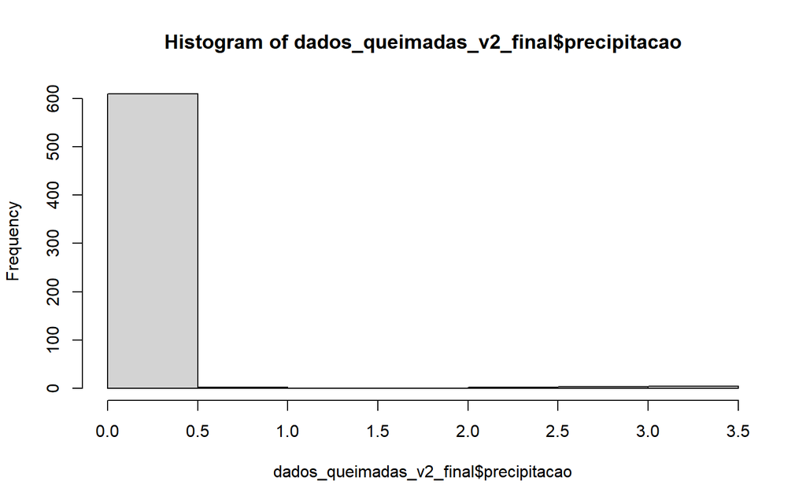

```r
hist(dados_queimadas_v2_final$precipitacao)
```

```r
par(mfrow=c(1,2))
```

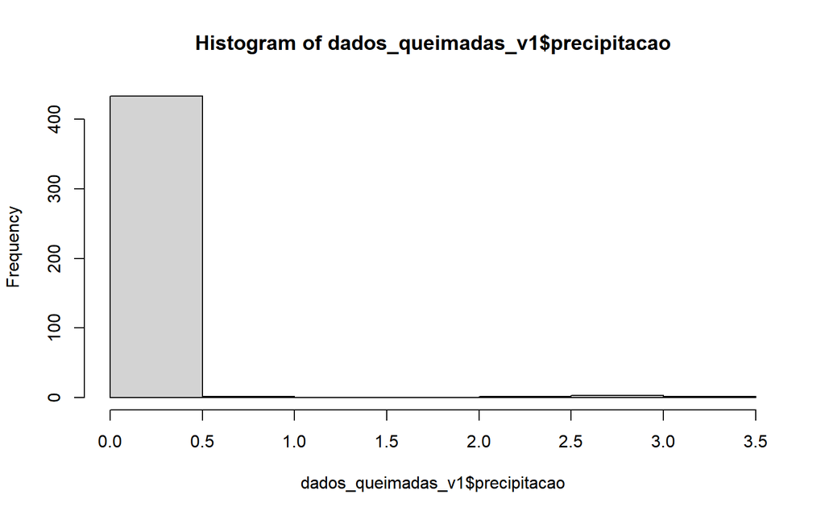

```r
hist(dados_queimadas_v1$precipitacao)
```

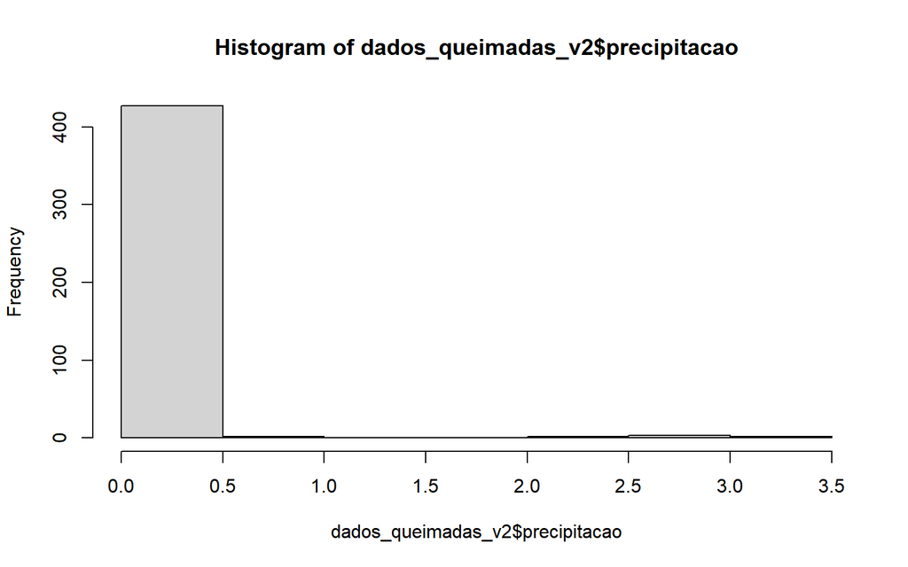

```r
hist(dados_queimadas_v2$precipitacao)
```

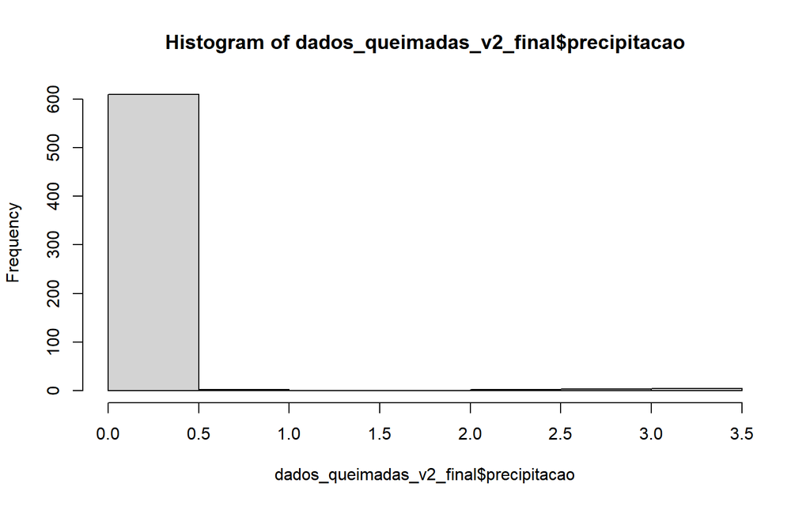

```r
hist(dados_queimadas_v2_final$precipitacao)
```

```r
par(mfrow=c(1,1))
```

```r
split.screen(figs=c(2,2))
```

```
## [1] 15 16 17 18
```

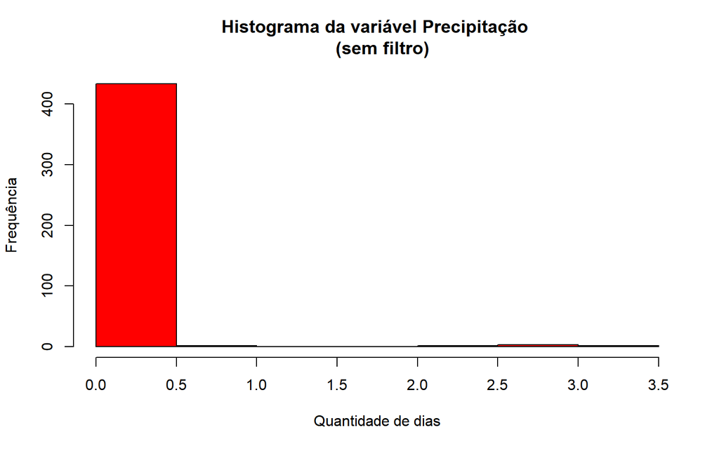

```r
hist(dados_queimadas_v1$precipitacao,
     main = "Histograma da variável Precipitação
  (sem filtro)",
     xlab = "Quantidade de dias",
     ylab = "Frequência",
     col = 'red')
```

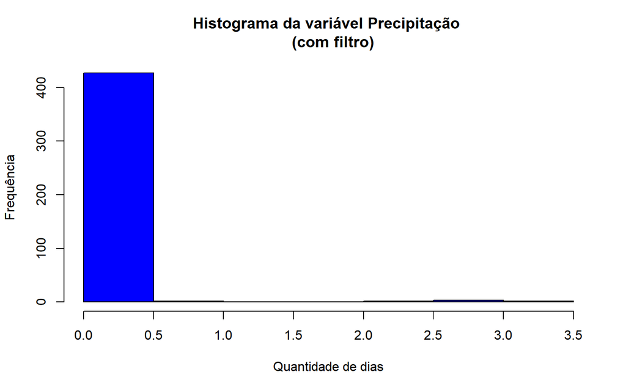

```r
hist(dados_queimadas_v2$precipitacao,
     main = "Histograma da variável Precipitação
  (com filtro)",
     xlab = "Quantidade de dias",
     ylab = "Frequência",
     col = 'blue')
```

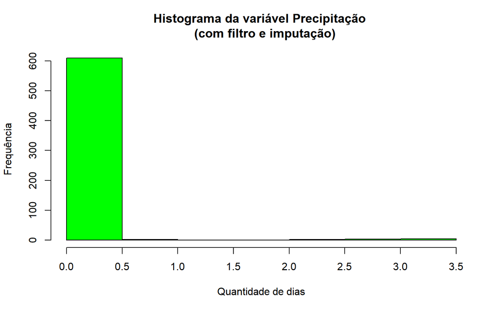

```r
hist(dados_queimadas_v2_final$precipitacao,
     main = "Histograma da variável Precipitação
  (com filtro e imputação)",
     xlab = "Quantidade de dias",
     ylab = "Frequência",
     col = 'green')
```

Comparativo do histograma da variável **frp** em três momentos da manipulação dos dados: (a) para o data frame original, (b) para o data frame após a aplicação do filtro para retirada de valores negativos e (c) após a aplicação do método de importação para a estimação de valores para os NA. A distribuição não é impactada.

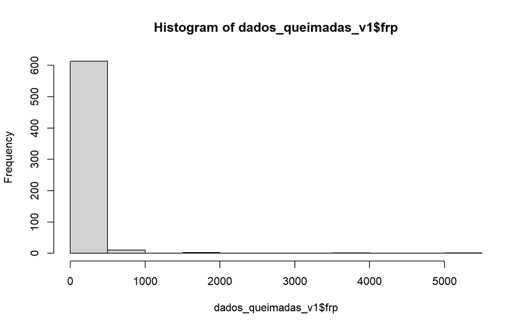

```r
hist(dados_queimadas_v1$frp)
```

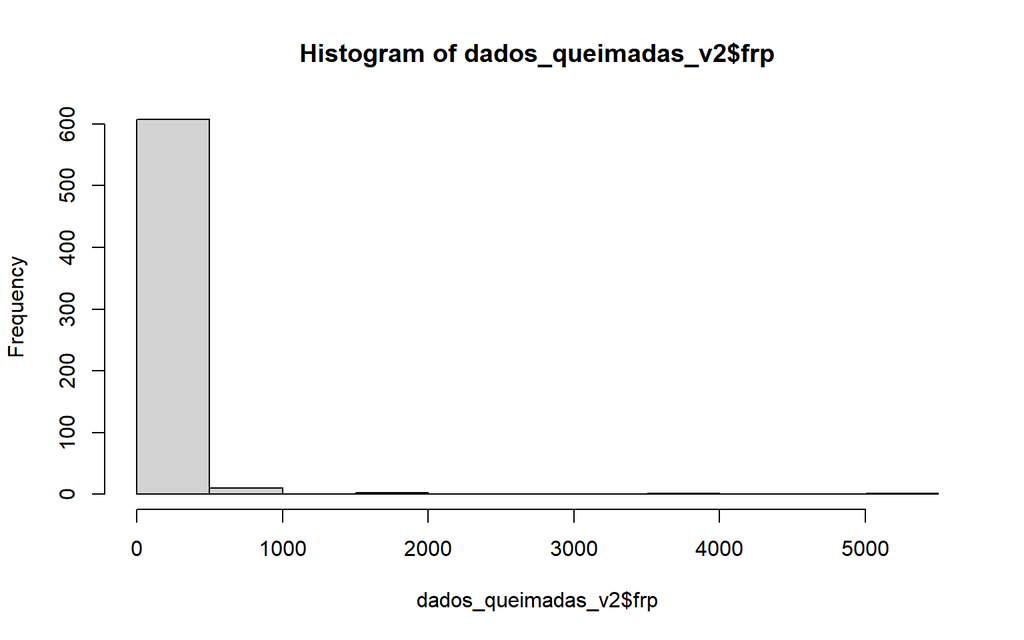

```r
hist(dados_queimadas_v2$frp)
```

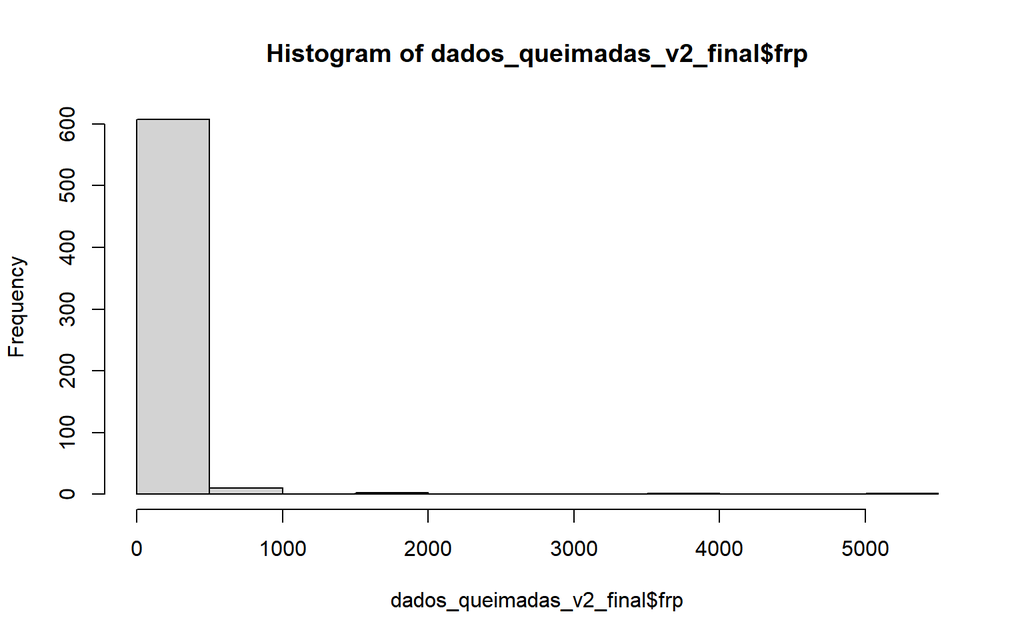

```r
hist(dados_queimadas_v2_final$frp)
```

```r
par(mfrow=c(1,2))
```

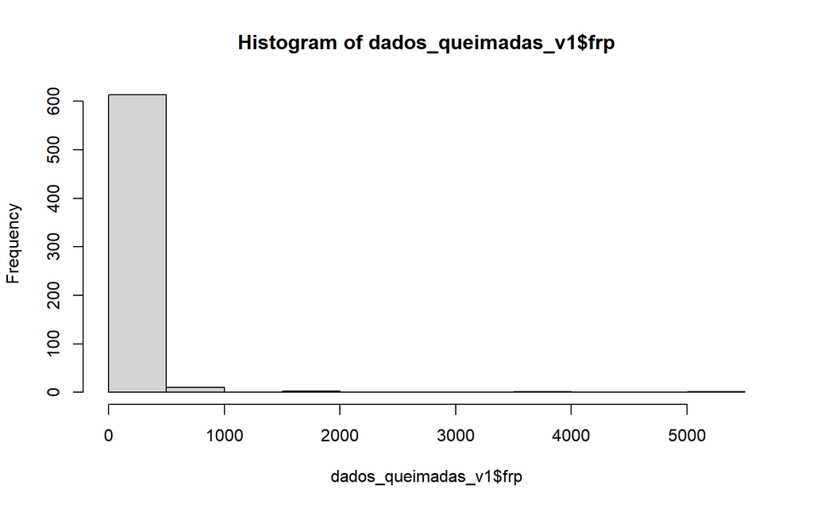

```r
hist(dados_queimadas_v1$frp)
```

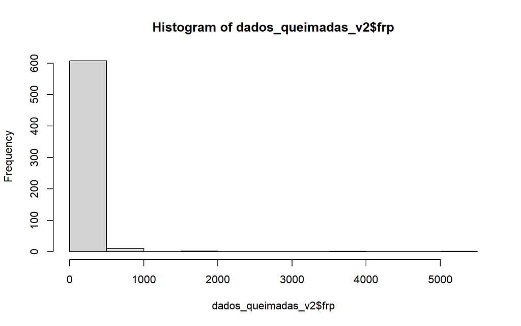

```r
hist(dados_queimadas_v2$frp)
```

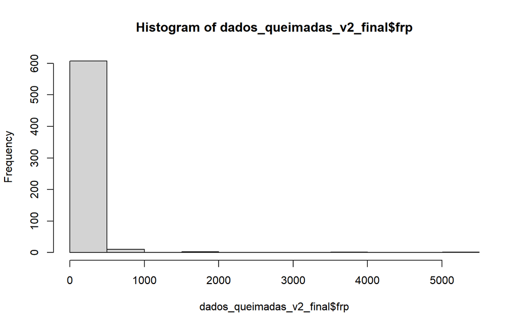

```r
hist(dados_queimadas_v2_final$frp)
```

```r
par(mfrow=c(1,1))
```

```r
split.screen(figs=c(2,2))
```

```
## [1] 19 20 21 22
```

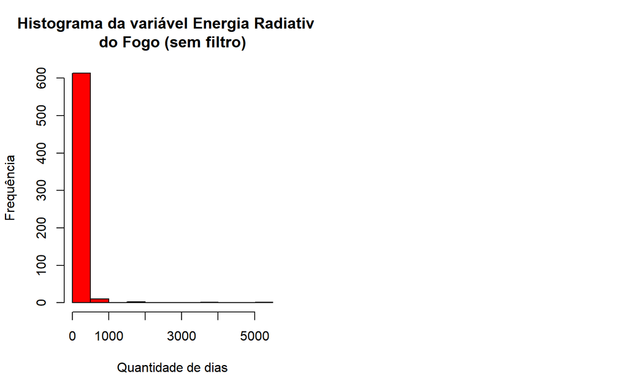

```r
screen(1)
hist(dados_queimadas_v1$frp,
     main = "Histograma da variável Energia Radiativa
do Fogo (sem filtro)",
     xlab = "Quantidade de dias",
     ylab = "Frequência",
     col = 'red')
```

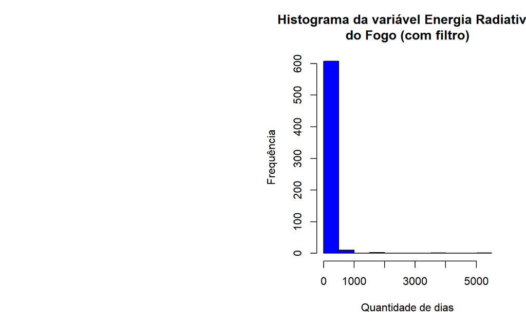

```r
screen(2)
hist(dados_queimadas_v2$frp,
     main = "Histograma da variável Energia Radiativa
do Fogo (com filtro)",
     xlab = "Quantidade de dias",
     ylab = "Frequência",
     col = 'blue')
```

[figure not shown]

```r
screen(3)
hist(dados_queimadas_v2_final$frp,
     main = "Histograma da variável Energia Radiativa
do Fogo (com filtro e imputação)",
     xlab = "Quantidade de dias",
     ylab = "Frequência",
     col = 'green')
```

A retomada da plotagem da função boxplot() permite avaliar a distribuição dos dados após a aplicação do filtro para retirada de valores negativos e da imputação de valores para posições com registros NA. Verifica-se ainda a presença de outliers nas variáveis **precipitacao, riscofogo e frp**.

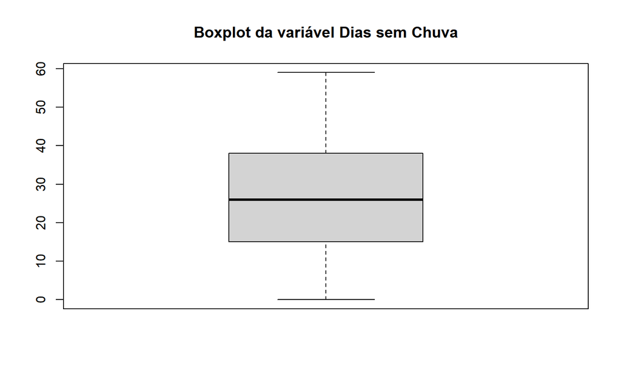

```r
boxplot(dados_queimadas_v2_final$diasemchuva, main = "Boxplot da variável Dias sem Chuva")
```

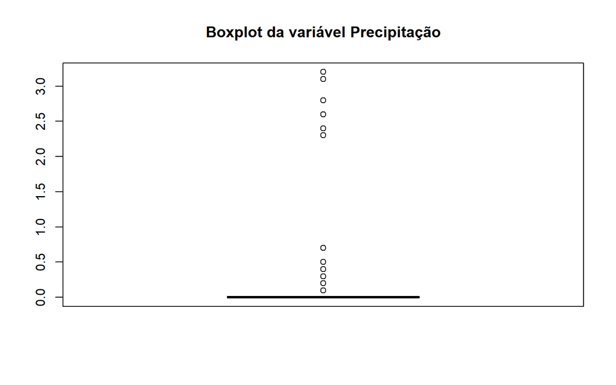

```r
boxplot(dados_queimadas_v2_final$precipitacao, main = "Boxplot da variável Precipitação")
```

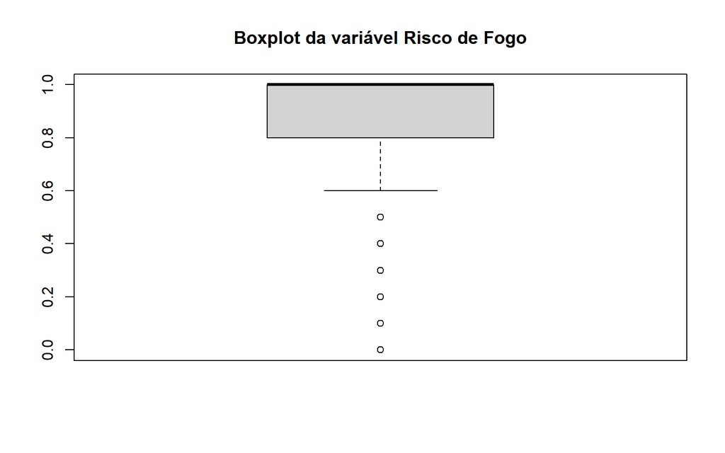

```r
boxplot(dados_queimadas_v2_final$riscofogo, main = "Boxplot da variável Risco de Fogo")
```

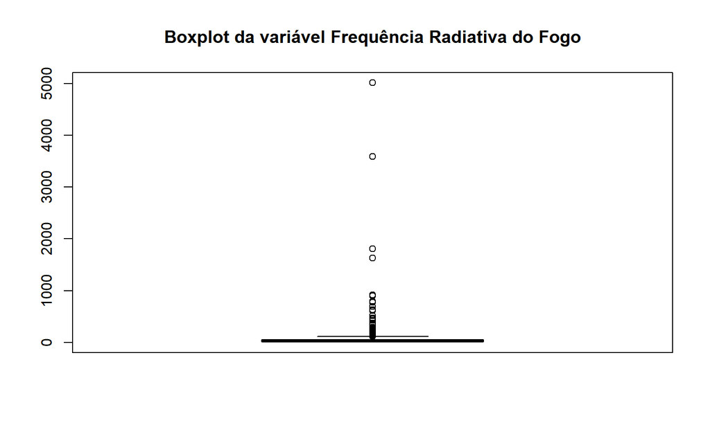

```r
boxplot(dados_queimadas_v2_final$frp, main = "Boxplot da variável Frequência Radiativa do Fogo")
```

Na sequência, foram aplicadas técnicas, como média, variância e desvio padrão, visando exploração dos dados a fim de se chegar a *insights*.

```r
diaschuva_municipio_antes<-aggregate(data = dados_queimadas_v2, diasemchuva ~ municipio, mean)
diaschuva_municipio_antes<-aggregate(data = dados_queimadas_v2_final, diasemchuva ~ municipio, mean)
```

```r
diaschuva_estado_antes<- aggregate(data = dados_queimadas_v2, diasemchuva ~ estado, mean)
diaschuva_estado_depois<- aggregate(data = dados_queimadas_v2_final, diasemchuva ~ estado, mean)
```

```r
aggregate(data = dados_queimadas_v2_final, cbind(diasemchuva,precipitacao,riscofogo,frp) ~ estado, mean)
```

```
##                 estado diasemchuva precipitacao riscofogo       frp
## 1                 ACRE    21.40000   0.68000000 0.4800000  21.04000
## 2             AMAZONAS    17.00000   0.06666667 0.3833333  16.23333
## 3                BAHIA    38.33333   0.00000000 1.0000000  25.81667
## 4                CEARA    44.00000   0.00000000 1.0000000   6.00000
## 5       ESPIRITO SANTO    16.33333   0.00000000 1.0000000 104.96667
## 6                GOIAS    16.37500   0.00000000 0.9593750  34.74063
## 7             MARANHAO    24.04878   0.07804878 0.9219512  48.02195
## 8          MATO GROSSO    28.68493   0.05296804 0.8283105 149.15936
## 9   MATO GROSSO DO SUL    15.23077   0.25384615 0.8769231  35.56923
## 10        MINAS GERAIS    17.10417   0.00000000 0.9854167  25.56250
## 11                PARA     8.28000   0.46400000 0.3640000  27.36400
## 12             PARAIBA    28.66667   0.06666667 1.0000000  15.00000
## 13              PARANA    10.18182   0.00000000 0.6727273  29.08182
## 14          PERNAMBUCO    33.00000   0.00000000 0.9666667  13.30000
## 15               PIAUI    30.16667   0.01388889 0.9305556  34.06111
## 16      RIO DE JANEIRO     8.00000   0.03333333 1.0000000  32.90000
## 17 RIO GRANDE DO NORTE    26.50000   0.00000000 0.9000000  39.60000
## 18            RONDONIA    16.10000   0.43000000 0.3700000  20.36000
## 19             RORAIMA    24.00000   0.20000000 0.5000000   7.70000
## 20           SAO PAULO    12.70370   0.05185185 0.9259259  67.02963
## 21           TOCANTINS    29.08036   0.00000000 0.9821429  33.66339
```

```r
aggregate(data = dados_queimadas_v2_final, cbind(diasemchuva,precipitacao,riscofogo,frp) ~ municipio, mean)
```

```
##                       municipio diasemchuva precipitacao riscofogo        frp
## 1                    ABAETETUBA    0.000000  2.350000000 0.0000000  15.300000
## 2                       ABAIARA   44.000000  0.000000000 1.0000000   6.000000
## 3                   ABREULANDIA   42.000000  0.000000000 1.0000000  20.000000
## 4                         ACARA    2.000000  0.000000000 0.0000000  22.600000
## 5                      AGUA BOA    3.000000  0.000000000 1.0000000  33.600000
## 6                 ALDEIAS ALTAS   35.000000  0.300000000 1.0000000  18.400000
## 7                         ALMAS   40.000000  0.000000000 0.9600000  61.460000
## 8                 ALTA FLORESTA   25.000000  1.966666667 0.6666667  59.933333
## 9                        ALTAIR   15.000000  0.000000000 1.0000000  91.983333
## 10               ALTO BOA VISTA   21.000000  0.000000000 1.0000000  71.900000
## 11                ALTO PARNAIBA   11.000000  0.000000000 1.0000000  83.300000
## 12                      AMAJARI   24.000000  0.200000000 0.5000000   7.700000
## 13                      AMAMBAI    2.000000  0.000000000 1.0000000  17.300000
## 14                 ANTONIO JOAO    9.000000  0.000000000 0.5000000  28.900000
```

[output cut: 210 more lines]

```r
var(dados_queimadas_v2_final$riscofogo)
```

```
## [1] 0.05657691
```

```r
var(dados_queimadas_v2_final$diasemchuva)
```

```
## [1] 186.6761
```

```r
var(dados_queimadas_v2_final$precipitacao)
```

```
## [1] 0.1349317
```

```r
var(dados_queimadas_v2_final$frp)
```

```
## [1] 78911.65
```

```r
sd(dados_queimadas_v2_final$riscofogo)
```

```
## [1] 0.237859
```

```r
sd(dados_queimadas_v2_final$diasemchuva)
```

```
## [1] 13.66295
```

```r
sd(dados_queimadas_v2_final$precipitacao)
```

```
## [1] 0.3673306
```

```r
sd(dados_queimadas_v2_final$frp)
```

```
## [1] 280.9122
```

Calculando o coeficiente de assimetria. A função skewness(), que indica o comportamento dos desvios em relação à média, agrega informação às tendências já observadas.

A variável **riscofogo**, apresenta assimetria negativa, com comportamento inverso, ou seja, valores concentrados à direita e uma cauda sinuosa à esquerda. Embora não se trate de uma simetria, a variável **diassemchuva** possui maior dispersão e distribuição dos dados.

```r
skewness(dados_queimadas_v2_final$diasemchuva)
```

```
## [1] -0.1514387
```

```r
skewness(dados_queimadas_v2_final$precipitacao)
```

```
## [1] 7.304613
```

```r
skewness(dados_queimadas_v2_final$riscofogo)
```

```
## [1] -2.051531
```

```r
skewness(dados_queimadas_v2_final$frp)
```

```
## [1] 12.77149
```

Curtose - função kurtosis() - está associada ao grau de achatamento em relação à normal padrão. Observa-se a distribuição mais afunilada, se valores maiores que zero (como nas variáveis **riscofogo**, **precipitação** e **frp**), ou o desenho mais achatado, se menores que zero (como ocorre com a variável diassemchuva).

Embora muito destaque seja dado à formação do pico, a curtose está mais intimamente ligada ao peso das caudas na distribuição e, portanto, diz da concentração ou dispersão dos valores em relação às medidas de tendência central.

```r
kurtosis(dados_queimadas_v2_final$diasemchuva)
```

```
## [1] -1.231653
```

```r
kurtosis(dados_queimadas_v2_final$riscofogo)
```

```
## [1] 3.726532
```

```r
kurtosis(dados_queimadas_v2_final$precipitacao )
```

```
## [1] 54.02088
```

```r
kurtosis(dados_queimadas_v2_final$frp)
```

```
## [1] 194.5906
```

```r
x = dados_queimadas_v2_final$diasemchuva
y = dados_queimadas_v2_final$riscofogo
cor(x,y)
```

```
## [1] 0.3184
```

```r
x = dados_queimadas_v2_final$precipitacao
y = dados_queimadas_v2_final$riscofogo
cor(x,y)
```

```
## [1] -0.4146544
```

```r
x = dados_queimadas_v2_final$frp
y = dados_queimadas_v2_final$riscofogo
cor(x,y)
```

```
## [1] -0.06923721
```

```r
cor(dados_queimadas_v2_final[c( "diasemchuva", "precipitacao", "riscofogo", "latitude","longitude","frp" )])
```

```
##              diasemchuva precipitacao   riscofogo    latitude   longitude
## diasemchuva   1.00000000  -0.15003298  0.31840002  0.18104054  0.05828814
## precipitacao -0.15003298   1.00000000 -0.41465436  0.13511512 -0.14686186
## riscofogo     0.31840002  -0.41465436  1.00000000 -0.25002846  0.43980307
## latitude      0.18104054   0.13511512 -0.25002846  1.00000000  0.07450248
## longitude     0.05828814  -0.14686186  0.43980307  0.07450248  1.00000000
## frp           0.02460223   0.02511743 -0.06923721 -0.01971455 -0.11317572
##                      frp
## diasemchuva   0.02460223
## precipitacao  0.02511743
## riscofogo    -0.06923721
## latitude     -0.01971455
## longitude    -0.11317572
## frp           1.00000000
```

Ao ser gerada a matriz de correlação entre as variáveis **diasemchuva**, **precipitacao**, **riscofogo**, **latitude** e **longitude** não se observa nenhuma relação ao mesmo tempo forte e positiva.

Entretanto, chama atenção o fato de a variável **riscofogo** ter uma relação positiva e moderada com as variáveis longitude e **diasemchuva** e uma relação negativa e moderada com a variável **precipitação**.

Ainda que seja fraca, vale destacar a correlação da variável **riscofogo** com as variáveis **latitude** e **frp** , ambas negativas.

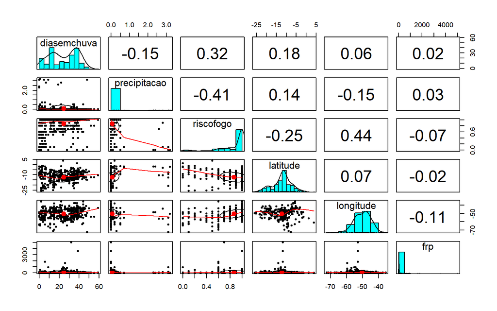

```r
pairs.panels(dados_queimadas_v2_final[c( "diasemchuva", "precipitacao", "riscofogo", "latitude","longitude","frp" )])
```

A função pairs() oferece um painel a partir do qual é possível visualizar como as variáveis de um conjunto de dados estão correlacionadas. Com maior coeficiente de correlação, destaca-se a relação entre **riscofogo** e **longitude**, sugerindo a relevância da localização geográfica na avaliação do fenômeno estudado.

Com a função prop.table(), foi verificado se a variável-alvo está balanceada. Muita concentração em 1.

```r
prop.table(table(dados_queimadas_v2_final$riscofogo)) * 100
```

```
##
##          0        0.1        0.2        0.3        0.4        0.5        0.6
##  1.6103060  2.4154589  1.1272142  0.4830918  1.6103060  1.2882448  6.7632850
##        0.7        0.8        0.9          1
##  6.2801932  8.6956522  5.6360709 64.0901771
```

```r
prop.table(table(dados_queimadas_v2_final$diasemchuva)) * 100
```

```
##
##          0          1          2          3          4          5          6
##  1.7713366  1.1272142  2.4154589  2.7375201  2.4154589  0.3220612  2.5764895
##          7          8          9         10         11         12         13
##  1.1272142  0.3220612  0.6441224  0.4830918  4.9919485  1.4492754  0.3220612
##         14         15         16         17         18         19         20
##  2.2544283 12.2383253  0.9661836  1.1272142  0.8051530  0.6441224  0.9661836
##         21         22         23         24         25         26         27
##  1.7713366  2.5764895  1.2882448  1.1272142  0.9661836  2.2544283  0.9661836
##         28         29         30         31         32         33         34
##  1.4492754  0.9661836  1.1272142  0.6441224  2.7375201  1.7713366  4.6698873
##         35         36         37         38         39         40         41
##  4.3478261  1.7713366  1.6103060  5.1529791 10.4669887  1.6103060  1.9323671
##         42         43         44         45         46         47         48
##  1.2882448  0.8051530  1.7713366  0.4830918  0.9661836  0.8051530  0.3220612
##         50         52         55         59
##  0.1610306  0.1610306  0.1610306  0.1610306
```

Muita concentração em 0

```r
prop.table(table(dados_queimadas_v2_final$precipitacao)) * 100
```

```
##
##          0        0.1        0.2        0.3        0.4        0.5        0.7
## 90.6602254  2.7375201  2.2544283  1.2882448  0.1610306  0.9661836  0.3220612
##        2.3        2.4        2.6        2.8        3.1        3.2
##  0.1610306  0.1610306  0.1610306  0.3220612  0.6441224  0.1610306
```

Verificando a frequência dos valores atribuídos à var1 - **riscofogo** - antes e depois da imputação. Percebe-se maior concentração de valores próximos a um.

```r
as.data.frame(table(dados_queimadas_v2$riscofogo))
```

```
##    Var1 Freq
## 1     0    5
## 2   0.1    9
## 3   0.2    3
## 4   0.3    2
## 5   0.4    4
## 6   0.5    6
## 7   0.6   25
## 8   0.7   30
## 9   0.8   45
## 10  0.9   28
## 11    1  279
```

```r
as.data.frame(table(dados_queimadas_v2_final$riscofogo))
```

```
##    Var1 Freq
## 1     0   10
## 2   0.1   15
## 3   0.2    7
## 4   0.3    3
## 5   0.4   10
## 6   0.5    8
## 7   0.6   42
## 8   0.7   39
## 9   0.8   54
## 10  0.9   35
## 11    1  398
```

Transformando variável do tipo character - **bioma** - em factor atribuindo uma codificação para elas. Isso é importante para algoritmos que não trabalham com valores categóricos e necessitam de dados de entrada numéricos.

```r
dados_queimadas_v3_final <-data.frame(dados_queimadas_v2_final)
dados_queimadas_v3_final$bioma <- as.factor(dados_queimadas_v3_final$bioma)
dados_queimadas_v3_final$diasemchuva<- as.numeric(dados_queimadas_v3_final$diasemchuva)
```

```r
str(dados_queimadas_v3_final)
```

```
## 'data.frame':    621 obs. of  12 variables:
##  $ datahora    : chr  "2021/06/26 17:00:00" "2021/06/26 17:00:00" "2021/06/26 17:00:00" "2021/06/26 17:00:00" ...
##  $ satelite    : chr  "AQUA_M-T" "AQUA_M-T" "AQUA_M-T" "AQUA_M-T" ...
##  $ pais        : chr  "Brasil" "Brasil" "Brasil" "Brasil" ...
##  $ estado      : chr  "SAO PAULO" "MATO GROSSO DO SUL" "SAO PAULO" "SAO PAULO" ...
##  $ municipio   : chr  "IBITINGA" "ANTONIO JOAO" "SANTA BARBARA D'OESTE" "CAPIVARI" ...
##  $ bioma       : Factor w/ 5 levels "Amazonia","Caatinga",..: 3 3 4 4 4 4 4 4 4 4 ...
##  $ diasemchuva : num  15 9 4 3 3 3 3 2 7 6 ...
##  $ precipitacao: num  0 0 0.1 0.3 0.3 0.3 0.3 0 0 0 ...
##  $ riscofogo   : num  1 0.5 1 1 1 1 0.9 1 0.8 0.8 ...
##  $ latitude    : num  -21.9 -22.3 -22.8 -22.9 -22.9 ...
##  $ longitude   : num  -48.8 -56 -47.5 -47.5 -47.5 ...
##  $ frp         : num  4.7 28.9 15.3 74.7 52.9 ...
```

```r
View(dados_queimadas_v3_final)
```

Dividindo os dados em treino 60% e teste 40%. Foram utilizados outros percentuais - 90/10 ou 80/20 - mas, em função do tamanho da amostra, optou-se por 60/40 (pela melhor performance). Além disso, optou-se pela seleção aleatória e sem reposição.

```r
indice_divisao_dos_dados <- sample(x = nrow(dados_queimadas_v3_final),
                              size = 0.6 * nrow(dados_queimadas_v3_final),
                              replace = FALSE)#amostra sem reposição
```

Separando os dados no data frame de treino - **dados_treino** (60%) - e no data frame de teste - **dados_teste** (40%).

```r
dados_treino <- dados_queimadas_v3_final[indice_divisao_dos_dados ,]
dados_teste <- dados_queimadas_v3_final[-indice_divisao_dos_dados ,]
```

## **Treinamento do modelo de regressão linear Nº1**

Ajustando o modelo de regressão linear múltiplo e atribuindo os dados ao data frame dados_treino.

```r
model_v1 <- lm(riscofogo ~ diasemchuva +precipitacao+ latitude + longitude + frp, data = dados_treino[,-c(1:6)])
previsao_treino_v1 <- predict(model_v1)
```

Testando o modelo Nº1 de regressão linear: o modelo foi alimentado com as variáveis **riscofogo, diassemchuva, precipitação, latitude, longitude e frp**. Foram retiradas as colunas de dados do tipo character e a variável target (que se deseja prever).

```r
teste_v1 <- dados_teste[,-c(1:6,9)] #retirando colunas de character e target
View(dados_teste)
View(teste_v1)
previsao_teste_v1 <- predict(model_v1,teste_v1)
summary(model_v1)
```

```
##
## Call:
## lm(formula = riscofogo ~ diasemchuva + precipitacao + latitude +
##     longitude + frp, data = dados_treino[, -c(1:6)])
##
## Residuals:
##      Min       1Q   Median       3Q      Max
## -0.85541 -0.07991  0.03181  0.10100  0.43957
##
## Coefficients:
##                Estimate Std. Error t value Pr(>|t|)
## (Intercept)   1.308e+00  8.363e-02  15.640  < 2e-16 ***
## diasemchuva   5.834e-03  6.627e-04   8.804  < 2e-16 ***
## precipitacao -1.775e-01  2.411e-02  -7.360 1.23e-12 ***
## latitude     -1.554e-02  1.902e-03  -8.168 5.15e-15 ***
## longitude     1.526e-02  1.606e-03   9.501  < 2e-16 ***
## frp           2.960e-06  4.086e-05   0.072    0.942
## ---
## Signif. codes:  0 '***' 0.001 '**' 0.01 '*' 0.05 '.' 0.1 ' ' 1
##
## Residual standard error: 0.1696 on 366 degrees of freedom
## Multiple R-squared:  0.4897, Adjusted R-squared:  0.4827
## F-statistic: 70.24 on 5 and 366 DF,  p-value: < 2.2e-16
```

```r
summary(model_v1)
```

```
##
## Call:
## lm(formula = riscofogo ~ diasemchuva + precipitacao + latitude +
##     longitude + frp, data = dados_treino[, -c(1:6)])
##
## Residuals:
##      Min       1Q   Median       3Q      Max
## -0.85541 -0.07991  0.03181  0.10100  0.43957
##
## Coefficients:
##                Estimate Std. Error t value Pr(>|t|)
## (Intercept)   1.308e+00  8.363e-02  15.640  < 2e-16 ***
## diasemchuva   5.834e-03  6.627e-04   8.804  < 2e-16 ***
## precipitacao -1.775e-01  2.411e-02  -7.360 1.23e-12 ***
## latitude     -1.554e-02  1.902e-03  -8.168 5.15e-15 ***
## longitude     1.526e-02  1.606e-03   9.501  < 2e-16 ***
## frp           2.960e-06  4.086e-05   0.072    0.942
## ---
## Signif. codes:  0 '***' 0.001 '**' 0.01 '*' 0.05 '.' 0.1 ' ' 1
##
## Residual standard error: 0.1696 on 366 degrees of freedom
## Multiple R-squared:  0.4897, Adjusted R-squared:  0.4827
## F-statistic: 70.24 on 5 and 366 DF,  p-value: < 2.2e-16
```

Detectando a colinearidade: quando duas ou mais variáveis preditoras são altamente correlacionadas, aumenta o erro padrão gerando estimativas instáveis para avaliar valores maiores que 5.

Os vifs - fator de inflação da variância - medem o quanto o coeficiente de regressão aumenta se houver correlação entre os preditores. Não há multicolinearidade se todos os vifs forem 1. Entretanto, os preditores estarão correlacionados, se todos os vifs forem maiores que 1.

```r
kable(vif(model_v1 ),align='c')
```

|  | x |
| --- | --- |
| diasemchuva | 1.066411 |
| precipitacao | 1.121661 |
| latitude | 1.108797 |
| longitude | 1.052768 |
| frp | 1.020710 |

Fazendo seleção de atributos com o método Akaike(AIC) que mede a qualidade do modelo estatístico. Quanto menor o valor, maior a qualidade e a simplicidade.

```r
step<-stepAIC(model_v1, direction='both', trace=FALSE)
summary(step)
```

```
##
## Call:
## lm(formula = riscofogo ~ diasemchuva + precipitacao + latitude +
##     longitude, data = dados_treino[, -c(1:6)])
##
## Residuals:
##      Min       1Q   Median       3Q      Max
## -0.85499 -0.07951  0.03197  0.10093  0.43956
##
## Coefficients:
##               Estimate Std. Error t value Pr(>|t|)
## (Intercept)   1.307291   0.083057  15.740  < 2e-16 ***
## diasemchuva   0.005837   0.000661   8.830  < 2e-16 ***
## precipitacao -0.177524   0.024063  -7.378 1.09e-12 ***
## latitude     -0.015538   0.001899  -8.181 4.67e-15 ***
## longitude     0.015244   0.001591   9.583  < 2e-16 ***
## ---
## Signif. codes:  0 '***' 0.001 '**' 0.01 '*' 0.05 '.' 0.1 ' ' 1
##
## Residual standard error: 0.1693 on 367 degrees of freedom
## Multiple R-squared:  0.4897, Adjusted R-squared:  0.4841
## F-statistic: 88.03 on 4 and 367 DF,  p-value: < 2.2e-16
```

Incluindo uma coluna com os valores previstos no dataset.

```r
dados_teste_com_previsoes <- cbind(dados_teste, previsao_teste_v1)
```

Colocando a variável target ao lado dos valores previstos.

```r
dados_teste_com_previsoes<- dados_teste_com_previsoes %>%
        select(datahora,satelite,pais,estado,municipio,bioma,diasemchuva,precipitacao,latitude,longitude,frp,riscofogo,previsao_teste_v1)
```

```r
View(dados_teste_com_previsoes)
```

## **Treinamento do modelo de regressão linear Nº2**

Ajustando o modelo de regressão linear múltiplo e atribuindo os dados ao data frame **model_v2**.

```r
model_v2 <- lm(riscofogo ~bioma  + diasemchuva + precipitacao + latitude + longitude + frp, data = dados_treino)
previsao_treino_v2 <- predict(model_v2)
```

Testando o modelo Nº2 de regressão linear: modelo foi alimentado com as variáveis **riscofogo, bioma, diassemchuva, precipitação, latitude, longitude e frp**. Foram retiradas as colunas de dados do tipo character e a variável target (que se deseja prever), mas foi incluída a variável bioma, que inicialmente era do tipo string e foi transformada com a função factor().

```r
teste_v2 <- dados_teste[,-c(1:5,9)] #retirando coluna de character e target
View(dados_teste)
View(teste_v2)
previsao_teste_v2 <- predict(model_v2,teste_v2)
View(previsao_teste_v1)
```

```r
summary(model_v2)
```

```
##
## Call:
## lm(formula = riscofogo ~ bioma + diasemchuva + precipitacao +
##     latitude + longitude + frp, data = dados_treino)
##
## Residuals:
##      Min       1Q   Median       3Q      Max
## -0.74031 -0.05470  0.01535  0.09728  0.43063
##
## Coefficients:
##                       Estimate Std. Error t value Pr(>|t|)
## (Intercept)          1.257e+00  1.104e-01  11.386  < 2e-16 ***
## biomaCaatinga       -2.262e-02  4.744e-02  -0.477  0.63379
## biomaCerrado         8.033e-02  2.439e-02   3.293  0.00109 **
## biomaMata Atlantica -9.212e-02  4.982e-02  -1.849  0.06525 .
## biomaPantanal        1.639e-01  8.445e-02   1.941  0.05309 .
## diasemchuva          5.286e-03  6.422e-04   8.231 3.41e-15 ***
## precipitacao        -1.598e-01  2.321e-02  -6.884 2.58e-11 ***
## latitude            -1.665e-02  2.378e-03  -7.000 1.25e-11 ***
## longitude            1.504e-02  2.082e-03   7.225 2.99e-12 ***
## frp                  1.235e-05  3.902e-05   0.316  0.75181
## ---
## Signif. codes:  0 '***' 0.001 '**' 0.01 '*' 0.05 '.' 0.1 ' ' 1
##
## Residual standard error: 0.1617 on 362 degrees of freedom
## Multiple R-squared:  0.541,  Adjusted R-squared:  0.5296
## F-statistic: 47.41 on 9 and 362 DF,  p-value: < 2.2e-16
```

## **Treinamento do modelo de regressão linear Nº3**

Ajustando o modelo de regressão linear múltiplo e atribuindo os dados ao data frame **model_v3**.

```r
model_v3 <- lm(riscofogo ~diasemchuva + precipitacao + latitude + longitude , data = dados_treino)
previsao_treino_v3 <- predict(model_v3)
```

Testando o modelo Nº3 de regressão linear: modelo foi alimentado com as variáveis **riscofogo, diassemchuva, precipitação, latitude e longitude**. Não foram incluídas as colunas de dados bioma e frp.

```r
teste_v3 <- dados_teste[,-c(1:6,9,12)]
View(dados_teste)
View(teste_v3)
previsao_teste_v3 <- predict(model_v3,teste_v3)
View(previsao_teste_v3)
```

```r
summary(model_v3)
```

```
##
## Call:
## lm(formula = riscofogo ~ diasemchuva + precipitacao + latitude +
##     longitude, data = dados_treino)
##
## Residuals:
##      Min       1Q   Median       3Q      Max
## -0.85499 -0.07951  0.03197  0.10093  0.43956
##
## Coefficients:
##               Estimate Std. Error t value Pr(>|t|)
## (Intercept)   1.307291   0.083057  15.740  < 2e-16 ***
## diasemchuva   0.005837   0.000661   8.830  < 2e-16 ***
## precipitacao -0.177524   0.024063  -7.378 1.09e-12 ***
## latitude     -0.015538   0.001899  -8.181 4.67e-15 ***
## longitude     0.015244   0.001591   9.583  < 2e-16 ***
## ---
## Signif. codes:  0 '***' 0.001 '**' 0.01 '*' 0.05 '.' 0.1 ' ' 1
##
## Residual standard error: 0.1693 on 367 degrees of freedom
## Multiple R-squared:  0.4897, Adjusted R-squared:  0.4841
## F-statistic: 88.03 on 4 and 367 DF,  p-value: < 2.2e-16
```

## **Treinamento do modelo de regressão linear Nº4**

Ajustando o modelo de regressão linear múltiplo e atribuindo os dados ao data frame **dados_treino_v2**,

Testando o modelo Nº4 de regressão linear: modelo foi alimentado com as variáveis **riscofogo, bioma, diassemchuva, precipitação, latitude, longitude e frp**. As variáveis latitude e longitude foram elevadas ao quadrado, por serem números negativos. Foi retirada coluna de variável do tipo character e a variável target (que se deseja prever).

```r
dados_treino_v2 <- dados_treino
dados_treino_v2$latitude <- dados_treino$latitude^2
dados_treino_v2$longitude <- dados_treino$longitude^2
dados_teste_v2 <- dados_teste
dados_teste_v2$latitude <- dados_teste$latitude^2
dados_teste_v2$longitude <- dados_teste$longitude^2
```

```r
model_v4 <- lm(riscofogo ~bioma  + diasemchuva + precipitacao + latitude + longitude + frp, data = dados_treino_v2)
previsao_treino_v4 <- predict(model_v4)
```

```r
teste_v4 <- dados_teste_v2[,-c(1:5,9)] #retirando coluna de character e target
View(dados_teste_v2)
View(teste_v4)
previsao_teste_v4 <- predict(model_v4,teste_v4)
summary(model_v4)
```

```
##
## Call:
## lm(formula = riscofogo ~ bioma + diasemchuva + precipitacao +
##     latitude + longitude + frp, data = dados_treino_v2)
##
## Residuals:
##      Min       1Q   Median       3Q      Max
## -0.74892 -0.05508  0.01749  0.10398  0.47115
##
## Coefficients:
##                       Estimate Std. Error t value Pr(>|t|)
## (Intercept)          9.124e-01  6.148e-02  14.840  < 2e-16 ***
## biomaCaatinga        3.635e-03  4.711e-02   0.077   0.9385
## biomaCerrado         1.008e-01  2.457e-02   4.101 5.09e-05 ***
## biomaMata Atlantica -6.036e-02  5.382e-02  -1.122   0.2628
## biomaPantanal        1.842e-01  8.714e-02   2.113   0.0352 *
## diasemchuva          5.503e-03  6.679e-04   8.238 3.23e-15 ***
## precipitacao        -1.737e-01  2.355e-02  -7.376 1.12e-12 ***
## latitude             5.054e-04  9.853e-05   5.129 4.75e-07 ***
## longitude           -1.235e-04  1.953e-05  -6.322 7.60e-10 ***
## frp                  1.601e-05  4.004e-05   0.400   0.6894
## ---
## Signif. codes:  0 '***' 0.001 '**' 0.01 '*' 0.05 '.' 0.1 ' ' 1
##
## Residual standard error: 0.166 on 362 degrees of freedom
## Multiple R-squared:  0.5164, Adjusted R-squared:  0.5044
## F-statistic: 42.95 on 9 and 362 DF,  p-value: < 2.2e-16
```

```r
summary(model_v4)
```

```
##
## Call:
## lm(formula = riscofogo ~ bioma + diasemchuva + precipitacao +
##     latitude + longitude + frp, data = dados_treino_v2)
##
## Residuals:
##      Min       1Q   Median       3Q      Max
## -0.74892 -0.05508  0.01749  0.10398  0.47115
##
## Coefficients:
##                       Estimate Std. Error t value Pr(>|t|)
## (Intercept)          9.124e-01  6.148e-02  14.840  < 2e-16 ***
## biomaCaatinga        3.635e-03  4.711e-02   0.077   0.9385
## biomaCerrado         1.008e-01  2.457e-02   4.101 5.09e-05 ***
## biomaMata Atlantica -6.036e-02  5.382e-02  -1.122   0.2628
## biomaPantanal        1.842e-01  8.714e-02   2.113   0.0352 *
## diasemchuva          5.503e-03  6.679e-04   8.238 3.23e-15 ***
## precipitacao        -1.737e-01  2.355e-02  -7.376 1.12e-12 ***
## latitude             5.054e-04  9.853e-05   5.129 4.75e-07 ***
## longitude           -1.235e-04  1.953e-05  -6.322 7.60e-10 ***
## frp                  1.601e-05  4.004e-05   0.400   0.6894
## ---
## Signif. codes:  0 '***' 0.001 '**' 0.01 '*' 0.05 '.' 0.1 ' ' 1
##
## Residual standard error: 0.166 on 362 degrees of freedom
## Multiple R-squared:  0.5164, Adjusted R-squared:  0.5044
## F-statistic: 42.95 on 9 and 362 DF,  p-value: < 2.2e-16
```

## **Conclusão**

Os insights gerados com base de dados oriunda da plataforma Programa Queimadas / Inpe podem ser sistematizados a partir de três momentos-chave deste estudo: (a) **a extração dos dados**; (b) a **análise exploratória dos dados**; (c) a **aplicação de experimentos de regressão linear**.

No processo decisório de seleção e de implementação de ferramentas e de métodos em ciência de dados e em machine learning, foram se desvelando limites, deslimites e demandas - neste caso, nem todas cumpridas - ao objetivo traçado de predição do fenômeno dos incêndios e das queimadas em contexto brasileiro. Isso permitiu a identificação, em cada uma dessas etapas, de **insights**, de **lacunas** / **falhas** e de **perspectivas futuras de investigação**.

**1a ETAPA**: extração automatizada de dados a partir da plataforma de dados abertos

**(A) INSIGHTS**:

- Base de dados amostral pequena;
- Volume de dados faltantes significativo;
- Valores negativos discrepantes acusando presença de outliers.
- Como o dataset foi descrito como pequeno, optou-se pela linguagem R, bem como pelo uso das plataformas Github e Git para o armazenamento e para o fluxo de trabalho colaborativo, com o benefício da possibilidade de versionamento.

  **(B) LACUNAS / FALHAS**:

  Investigação da natureza dos outliers e dos dados faltantes;

  Investigação / Pesquisa da natureza do fenômeno estudado e das variáveis que compõem a base de dados abertos do Programa Queimadas/Inpe.

Entrevista / Pesquisa para identificar o modelo de negócios que sustenta a plataforma Programa Queimadas / Inpe para melhor direcionamento do fluxo de trabalho diário automatizado para extração e para o armazenamento dos dados coletados em arquivo *.csv no diretório do Github.

**(C) PERSPECTIVAS FUTURAS DE INVESTIGAÇÃO:**

Entrevista com especialistas para compreender o modelo de negócios que sustenta a base de dados da plataforma Programa Queimadas / Inpe: o processo de coleta dos dados, a natureza e o sistema de valoração das variáveis da base de dados e as razões dos NAs e outliers.

Entrevista com especialistas para compreender a natureza do fenômeno estudado - queimadas e incêndios - no contexto brasileiro: sazonalidade, especificidades regionais e aspectos históricos e culturais.

Entrevista com especialistas para compreender a relação entre o fenômeno estudado, os indicadores geoeconômicos, as políticas públicas e as práticas de desenvolvimento econômico sustentável para a proteção do meio ambiente.

Extração de dados a partir da perspectiva regional. Muito embora a exploração inicial dos dados possa sugerir a influência de aspectos regionais geo-climáticos, o grau de profundidade da investigação, os métodos e ferramentas aplicados e os dados obtidos não permitem ampliar as inferências realizadas com os experimentos.

**2a ETAPA**: análise exploratória de dados.

**(A) INSIGHTS:**

Distribuição assimétrica dos dados, com outliers e concentração de dados sugerindo erro na coleta e / ou provável tendência de comportamento das variáveis.

Quadro comparativo do comportamento das variáveis antes de depois da aplicação do filtro de valores negativos e da imputação para dados ausentes.

Identificação e implementação de funções e de métodos para correção dos dados faltantes e outliers, tendo a preocupação de manter o perfil de distribuição da amostra, para posterior aplicação dos modelos de regressão linear.

**(B)LACUNAS / FALHAS:**

Explorar as medidas de dispersão e as medidas de tendência central, bem como de gráficos, e estabelecer relações a partir do comportamento das variáveis tendo em vista que este pode estar ligado a aspectos geo-climáticos regionais e à sazonalidade do fenômeno estudado.

Explorar os sistemas de valoração das variáveis **(riscofogo, precipitação, diasemchuva, longitude e latitude)** para ver como eles refletem aspectos geo-climáticos regionais e a sazonalidade do fenômeno estudado.

**(C) PERSPECTIVAS FUTURAS DE INVESTIGAÇÃO:**

Verificar se o comportamento das variáveis - revelado pelas medidas de dispersão e pelas medidas de tendência central, bem como de gráficos - pode estar associado a aspectos geo-climáticos regionais e à sazonalidade do fenômeno estudado.

Compreender os sistemas de valoração das variáveis e como eles podem estar ligados a aspectos geo-climáticos regionais e à sazonalidade do fenômeno estudado.

**3a ETAPA:** experimentos com aplicação de modelos de regressão linear.

**(A) INSIGHTS:**

Divisão do dataset para treinamento e para teste em 60% / 40%, uma vez que esta proporção resultou em melhor performance se comparada com as proporções 90% / 10% e 80% / 20%, que também foram experimentadas.

Embora os modelos empregados não tenham se mostrado com elevada acurácia na predição do fenômeno estudado, os experimentos sugerem correlação entre a variável target - riscofogo - e variáveis preditoras - longitude, diasemchuva, bioma e precipitação.

**(B) LACUNAS / FALHAS:**

Houve a tentativa de aplicar o modelo de árvore de decisão, mas a equipe não conseguiu incorporar os resultados obtidos com esse experimento.

**(C) PERSPECTIVAS FUTURAS DE INVESTIGAÇÃO:**

Aplicar o modelo de árvore de decisão. Verificar como os resultados obtidos na aplicação dos experimentos podem estar associados a aspectos geo-climáticos regionais e à sazonalidade do fenômeno estudado a fim de balizar ações de proteção ao meio ambiente.

Portanto, conclui-se que este trabalho é uma exploração, ainda inicial, de ferramentas e de métodos em ciência de dados e em machine learning. Acredita-se que ele abre espaço para a formulação de relatórios técnicos acerca do fenômeno estudado. Vale destacar que o alerta de especialistas para os impactos das queimadas e incêndios nas mudanças climáticas verificadas em todo o planeta impõe ações de proteção ao meio ambiente não somente por parte dos gestores públicos brasileiros, mas a toda a sociedade, seja a nível nacional, seja a nível internacional.

A equipe se mostra interessada, sobretudo pelo compromisso ético em aplicar as técnicas e os métodos em prol de uma demanda premente para o desenvolvimento econômico sustentável, em dar continuidade ao trabalho iniciado dentro dos esforços lançados pela Data Science Academy, na segunda temporada do Programa de Mentoria entre Alunos. Acredita-se que, por sua natureza multidisciplinar, com profissionais de diferentes áreas - direito, tecnologia da informação, estatística, engenharia agronômica e comunicação social - o grupo possa ampliar o escopo das análises apresentadas.

Por isso, diante dos desafios experimentados (delimitação do tema, investigação do fenômeno, escolha de ferramentas e métodos, obtenção de insights, etc), ao longo de quatro meses, a equipe agradece o espaço de mentoria que possibilitou a formação de um grupo de trabalho, com diferentes competências - ainda que em diferentes estágios de formação em ciência de dados - e em um ambiente colaborativo.

## **Referências**

- Monitoramento dos Focos Ativos por Países:  
  https://queimadas.dgi.inpe.br/queimadas/portal-static/estatisticas_paises/
- Risco de Fogo - Programa Queimadas - INPE:  
  https://queimadas.dgi.inpe.br/queimadas/fip-risco/